# individual2

Audrey Comer

4/17/2019

```r
acc <- read.csv("https://raw.githubusercontent.com/xdaiISU/ds202materials/master/hwlabs/fars2017/accident.csv", stringsAsFactors = FALSE)
names(acc)
```

```
##  [1] "STATE"      "ST_CASE"    "VE_TOTAL"   "VE_FORMS"   "PVH_INVL"
##  [6] "PEDS"       "PERNOTMVIT" "PERMVIT"    "PERSONS"    "COUNTY"
## [11] "CITY"       "DAY"        "MONTH"      "YEAR"       "DAY_WEEK"
## [16] "HOUR"       "MINUTE"     "NHS"        "RUR_URB"    "FUNC_SYS"
## [21] "RD_OWNER"   "ROUTE"      "TWAY_ID"    "TWAY_ID2"   "MILEPT"
## [26] "LATITUDE"   "LONGITUD"   "SP_JUR"     "HARM_EV"    "MAN_COLL"
## [31] "RELJCT1"    "RELJCT2"    "TYP_INT"    "WRK_ZONE"   "REL_ROAD"
## [36] "LGT_COND"   "WEATHER1"   "WEATHER2"   "WEATHER"    "SCH_BUS"
## [41] "RAIL"       "NOT_HOUR"   "NOT_MIN"    "ARR_HOUR"   "ARR_MIN"
## [46] "HOSP_HR"    "HOSP_MN"    "CF1"        "CF2"        "CF3"
## [51] "FATALS"     "DRUNK_DR"
```

```r
acc
```

[output not shown]

[output cut: 13454 more lines]

```r
per <- read.csv("https://raw.githubusercontent.com/xdaiISU/ds202materials/master/hwlabs/fars2017/person.csv", stringsAsFactors = FALSE)
names(per)
```

```
##  [1] "STATE"      "ST_CASE"    "VE_FORMS"   "VEH_NO"     "PER_NO"
##  [6] "STR_VEH"    "COUNTY"     "DAY"        "MONTH"      "HOUR"
## [11] "MINUTE"     "RUR_URB"    "FUNC_SYS"   "HARM_EV"    "MAN_COLL"
## [16] "SCH_BUS"    "MAKE"       "MAK_MOD"    "BODY_TYP"   "MOD_YEAR"
## [21] "TOW_VEH"    "SPEC_USE"   "EMER_USE"   "ROLLOVER"   "IMPACT1"
## [26] "FIRE_EXP"   "AGE"        "SEX"        "PER_TYP"    "INJ_SEV"
## [31] "SEAT_POS"   "REST_USE"   "REST_MIS"   "AIR_BAG"    "EJECTION"
## [36] "EJ_PATH"    "EXTRICAT"   "DRINKING"   "ALC_DET"    "ALC_STATUS"
## [41] "ATST_TYP"   "ALC_RES"    "DRUGS"      "DRUG_DET"   "DSTATUS"
## [46] "DRUGTST1"   "DRUGTST2"   "DRUGTST3"   "DRUGRES1"   "DRUGRES2"
## [51] "DRUGRES3"   "HOSPITAL"   "DOA"        "DEATH_DA"   "DEATH_MO"
## [56] "DEATH_YR"   "DEATH_HR"   "DEATH_MN"   "DEATH_TM"   "LAG_HRS"
## [61] "LAG_MINS"   "P_SF1"      "P_SF2"      "P_SF3"      "WORK_INJ"
## [66] "HISPANIC"   "RACE"       "LOCATION"
```

```r
per
```

[output not shown]

[output cut: 13225 more lines]

**Part One: Accident Data**

Are there some days of the week where more accidents happen than on others (use variable DAY_WEEK)?

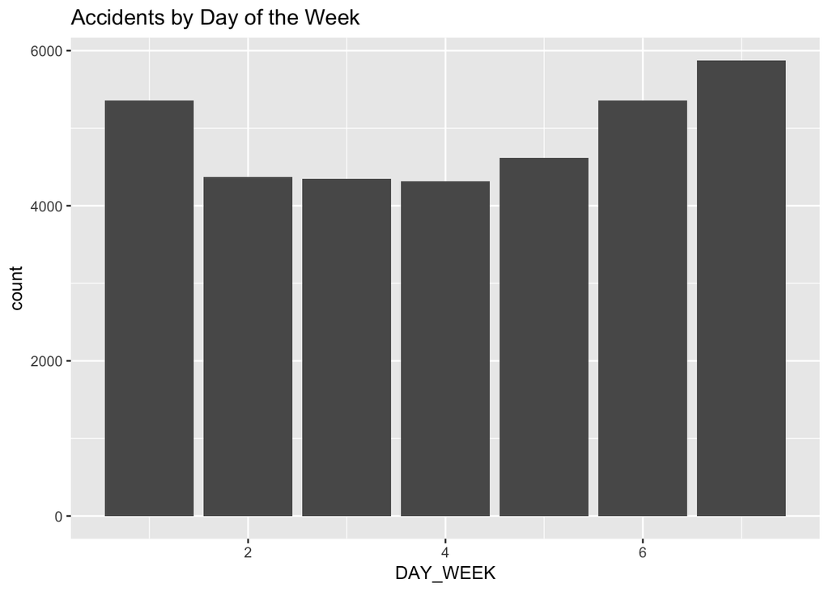

```r
library(ggplot2)
library(dplyr)
ggplot(acc, aes(x=DAY_WEEK)) + geom_bar() + labs(title='Accidents by Day of the Week')
```

According to the barchart, Saturdays and Sundays are more prone to accidents. This may be because these are travel days for some, days to run errands, etc. In other words, more people are out using the roads.

What time of the day do accidents happen (use variable HOUR)?

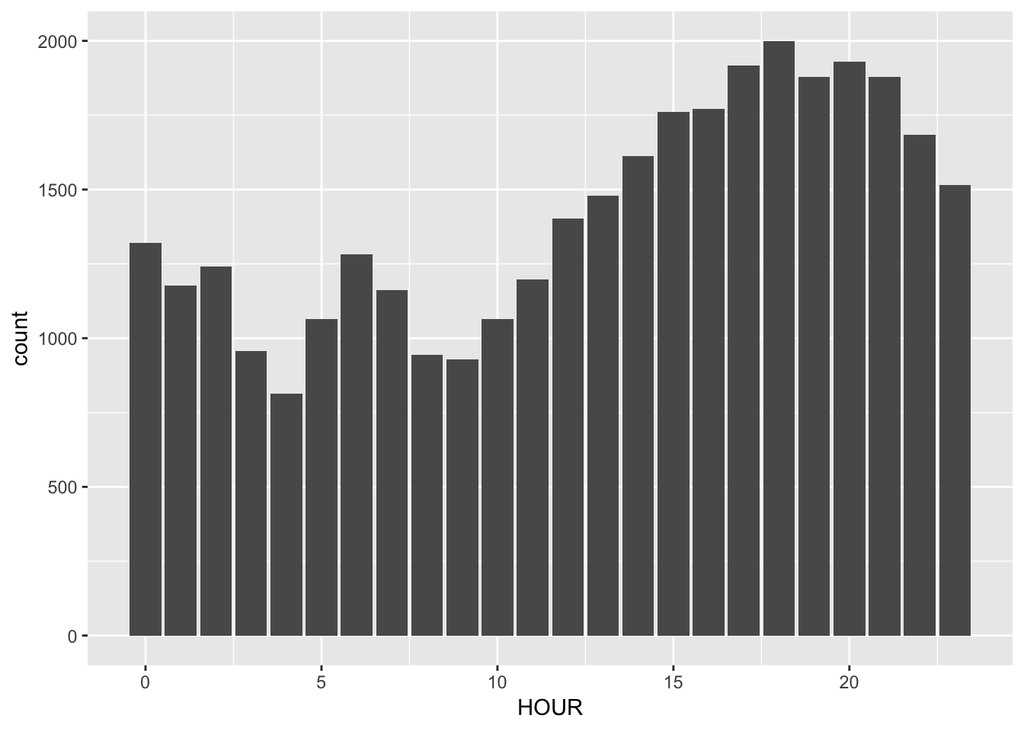

```r
acc %>% filter(HOUR <25) %>%
  ggplot(aes(x=HOUR)) + geom_bar()
```

According to the bar chart, the later evenings from 5 to 9 p.m. are more prone to accidents.

What is the number of accidents with at least one drunk driver (use variable DRUNK_DR)?

```r
sum(acc$DRUNK_DR >= 1)
```

```
## [1] 8769
```

There are 8769 accidents with at least one drunk driver in this dataset.

**Part Two: Connecting Data**

Identify drivers (PER_TYP == 1) and subset on them.

```r
per1 <- per %>% filter(PER_TYP == 1)
```

Join accident and driver table (work out which variable(s) to use).

```r
inner_join(acc, per, by = c("COUNTY", "DAY", "MONTH"))
```

[output not shown]

[output cut: 12811 more lines]

Tally the number of accidents by day of the week (DAY_WEEK), hour of the day (HOUR) and gender (SEX). Visualize results.

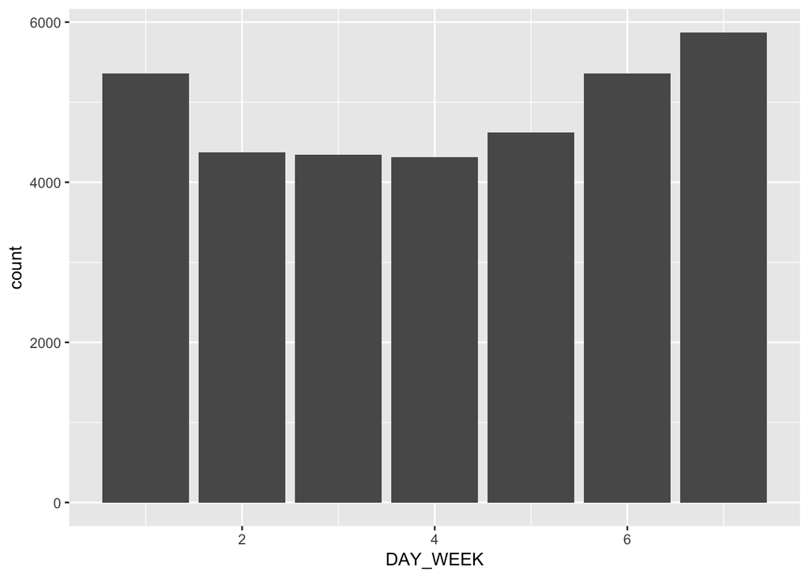

```r
ggplot(acc, aes(x=DAY_WEEK)) + geom_bar()
```

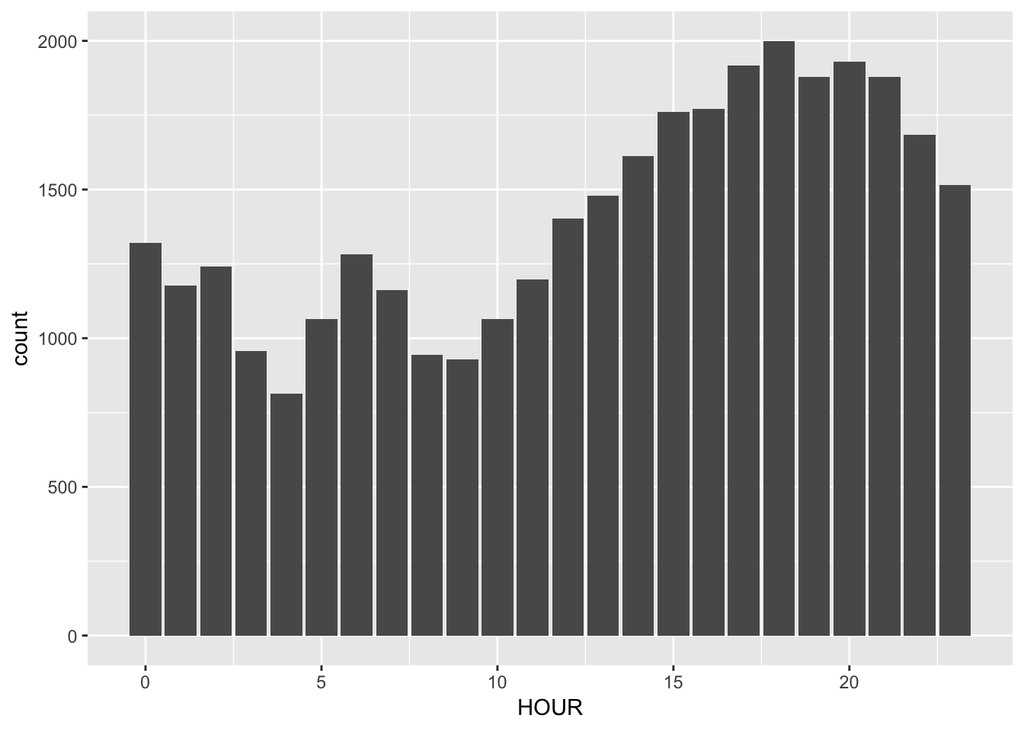

```r
acc %>% filter(HOUR < 25) %>% ggplot(aes(x=HOUR)) + geom_bar()
```

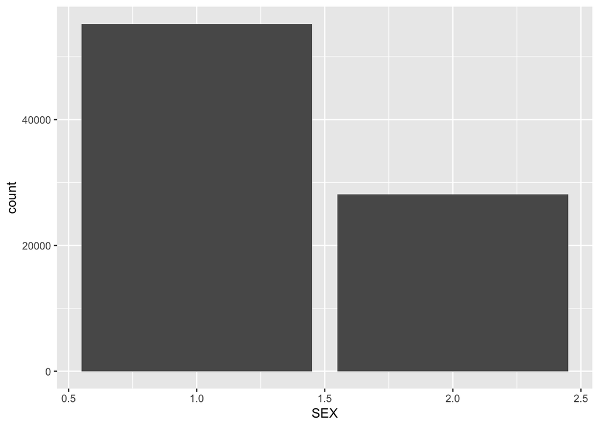

```r
per %>% filter(SEX<3) %>% ggplot(aes(x=SEX)) + geom_bar()
```

**Part Three: Connecting data and make maps**

```r
#will need to download the excel file from the link on the slides
library(readxl)
states <- read_excel('FRPP GLC United States.xlsx')
```

[output not shown]

```r
str(states)
```

```
## Classes 'tbl_df', 'tbl' and 'data.frame':    39674 obs. of  10 variables:
##  $ For Official Use Only: chr  "Territory" "U" "U" "U" ...
##  $ ..2                  : chr  "State Name" "ALABAMA" "ALABAMA" "ALABAMA" ...
##  $ ..3                  : chr  "State Code" "1" "1" "1" ...
##  $ ..4                  : chr  "City Code" "10" "50" "60" ...
##  $ ..5                  : chr  "City Name" "ABBEVILLE" "ALBERTVILLE" "ALEXANDER CITY" ...
##  $ ..6                  : chr  "County Code" "67" "95" "123" ...
##  $ ..7                  : chr  "County Name" "HENRY" "MARSHALL" "TALLAPOOSA" ...
##  $ ..8                  : chr  "Country Code" "840" "840" "840" ...
##  $ ..9                  : chr  "Old City Name" NA NA NA ...
##  $ ..10                 : chr  "Date Record Added" NA NA NA ...
```

```r
colnames(states) <- as.character(unlist(states[1,]))
states = states[-1, ]
```

```r
#will need to download the excel file from the link on the slides
territories <- read_excel('FRPP GLC US Territories.xlsx')
```

[output not shown]

```r
str(territories)
```

```
## Classes 'tbl_df', 'tbl' and 'data.frame':    221 obs. of  10 variables:
##  $ For Official Use Only: chr  "Territory" "T" "T" "T" ...
##  $ ..2                  : chr  "Territory Name" "AMERICAN SAMOA" "AMERICAN SAMOA" "AMERICAN SAMOA" ...
##  $ ..3                  : chr  "Territory Abbreviation" "AQ" "AQ" "AQ" ...
##  $ ..4                  : chr  "City Name" "APPIA" "EASTERN DISTRICT" "MANNA" ...
##  $ ..5                  : chr  "City Code" "0800" "1000" "2000" ...
##  $ ..6                  : chr  "County Name" NA "EASTERN" NA ...
##  $ ..7                  : chr  "County Code" NA "010" NA ...
##  $ ..8                  : chr  "Old Country Code" "060" "060" "060" ...
##  $ ..9                  : chr  "New Country Code" "016" "016" "016" ...
##  $ ..10                 : chr  "Date Record Added" NA NA NA ...
```

```r
territories
```

```
## # A tibble: 221 x 10
##    `For Official Us… ..2    ..3   ..4   ..5   ..6   ..7   ..8   ..9   ..10
##    <chr>             <chr>  <chr> <chr> <chr> <chr> <chr> <chr> <chr> <chr>
##  1 Territory         Terri… Terr… City… City… Coun… Coun… Old … New … Date…
##  2 T                 AMERI… AQ    APPIA 0800  <NA>  <NA>  060   016   <NA>
##  3 T                 AMERI… AQ    EAST… 1000  EAST… 010   060   016   <NA>
##  4 T                 AMERI… AQ    MANNA 2000  <NA>  <NA>  060   016   <NA>
##  5 T                 AMERI… AQ    PAGO… 6000  EAST… 010   060   016   <NA>
##  6 T                 AMERI… AQ    ROSE… 7000  ROSE… 030   060   016   <NA>
##  7 T                 AMERI… AQ    SWAI… 9000  SWAI… 040   060   016   <NA>
##  8 T                 AMERI… AQ    TUTU… 8000  EAST… 010   060   016   <NA>
##  9 T                 AMERI… AQ    TUTU… 8000  WEST… 050   060   016   <NA>
## 10 T                 AMERI… AQ    WEST… 9990  WEST… 050   060   016   <NA>
## # … with 211 more rows
```

```r
colnames(territories) <- as.character(unlist(territories[1,]))
territories = territories[-1, ]
```

Join: change State$`State Code` to numeric, same with county code

```r
states$STATE <- as.numeric(states$`State Code`)
states$COUNTY <- as.numeric(states$`County Code`)
states$CITY <- as.numeric(states$`City Code`)
```

Plot a choropleth map of accidents on a county level.

[figure not shown]

```r
#acc %>% filter(LONGITUD <0) %>%
 # ggplot(aes(x = LONGITUD, y = LATITUDE)) +
  #geom_point()
usmap <- map_data("county")
map <- acc %>% left_join(states, by="COUNTY")
#map1 <- map2 %>% left_join(usmap, by="region")

map %>%
  ggplot(aes(x = LONGITUD, y = LATITUDE)) +
  geom_polygon(aes(group=COUNTY))
```

Can you find seasonal trends in accident occurrences in different states? Is summer or winter more dangerous? Why?

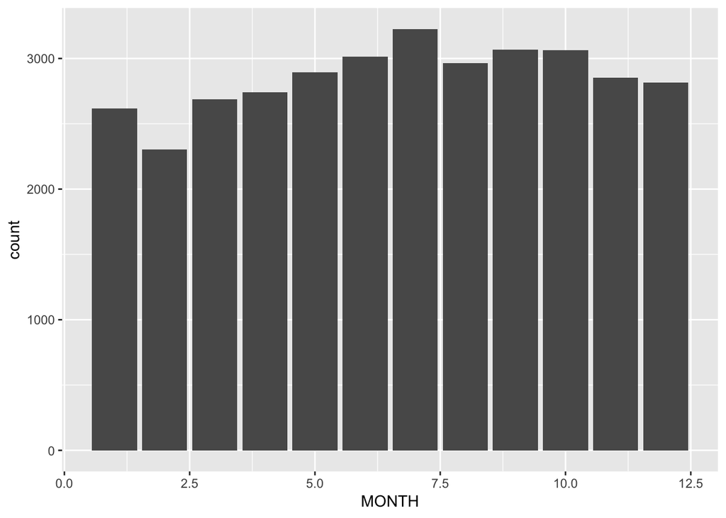

```r
acc %>% ggplot(aes(x= MONTH)) + geom_bar()
```

June, July, September October look to be the months with the most accidents. I would expect June and July because of it being summer time in the United States. In other words, there are more people going on vacations and travelling, leading to a higher chance of accidents occuring.